# Algorithm Class - Practice 4 - Linked List and Java List

2018/7/6

# Linked List

```java
class ListNode {
  public int value;  //any type
  public ListNode next;
  //public ListNode prev;
  public ListNode(int value) {
    this.value = value;
    this.next = null;
  }
}

ListNode head = new ListNode(3);
head.next = new ListNode(4);
```

**To represent sequence of elements: array/list**

array: {1, 2, 3} - the elements are stored in consecutive memory

list: {1, 2, 3} - the elements are not stored in consecutive space, but are connected by the “next” pointer/references

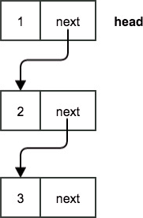

**For list, we need to always know where the “HEAD” is, so that we can traverse (遍歷) / find any elements in the list by iterating the “next” reference.**

# Array vs. Linked List Comparison

- Memory Layout
  - Array: consecutive allocated memory space, no overhead
  - Linked List: non-consecutive, overhead of multiple objects with the “next” reference
- (Random) access time? get the i-th element
  - Array: O(1) –> calculating the offset is O(1). `int value = array[5];`
  - Linked List: O(n) worst case –> we can only traverse from the **HEAD**
- Search time (non-sorted)?
  - Array: O(n)
  - Linked List: O(n)
- Search time (sorted)
  - Array: O($\log{n}$)
  - Linked List: O(n)
    - Reason: random access time is different for array and list.

# Objects, References, null in linked list operations

```java
class ListNode {
  public int value;
  public ListNode next;
  public ListNode prev;  //Doubly Linked List, very powerful, covered later.
  public ListNode(int value) {
    this.value = value;
    this.next = null;
  }
}
```

Let’s review this block of codes first.

```java
//片段
ListNode current = null;
ListNode next = null;
current = new ListNode(0);
next = new ListNode(1);
ListNode temp = current;  //temp
current.next = next;  //current.next在heap上,要改變連接邏輯必須要在heap上發生
current = current.next;
```

**What is current, temp, next at this point finishing all the lines above?**

- `current.value`? - 1
- `next.value`? - 1
- `temp.value`? - 0

null - the reference is not pointed to any Object on the Heap. (不指向任何一個Object的名片)

- A special value for reference

```java
ListNode current = null;
ListNode next = null;
```

Initialize to null, not pointing to any concrete object in the heap.

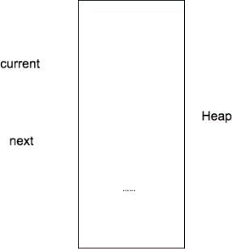

```java
current = new ListNode(0);
```

1. allocate space on heap and create a new ListNode object with {value = 0, next = null}
2. return the object’s memory address as the value of reference.

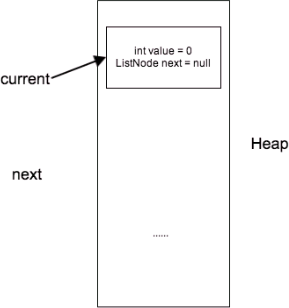

```java
next = new ListNode(1);
```

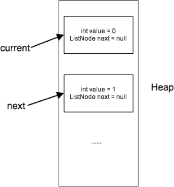

```java
ListNode temp = current;
```

`temp` will be assigned the same value as `current`, which means `temp` is pointed to the same ListNode object where `current` is pointed to.

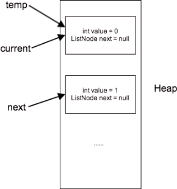

```java
current.next = next;
```

Dereferencing `current` to find the actual ListNode object, change the `next` field.

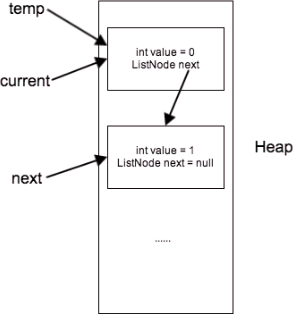

```java
current = current.next;
```

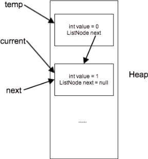

**What about we adding these two lines after? What would be the result?**

```java
temp.next = temp.next.next;  //斷了
```

what if:

```java
current.next = current.next.next;  //(null).next
//NullPointerException (NPE). 把"值"賦給null (null.next)
```

Dereference null -> NullPointerException

# Linked List Operations

## length()

**Example**

- 1 –> 2 –> 3 –> null, return 3
- 1 –> 2 –> null, return 2

```java
int length(ListNode head) {
  int linkedListSize = 0;
  ListNode current = head;
  while (current != null) {
    current = current.next;
    linkedListSize = linkedListSize + 1;
  }
  //current == null;
  return linkedListSize;
}
```

## get(index)

**Example**

- 1 –> 2 –> 3 –> null
- index = 0 –> return 1
- index = 4 –> return null

```java
ListNode get(ListNode head, int index) {
  int currentIndex = 0;
  ListNode temp = head;
  while (currentIndex < index) {
    if (temp == null) {
      return null;
    }
    temp = temp.next;
    currentIndex = currentIndex + 1;
  }
  //currentIndex >= index;
  return temp;
}
```

```java
ListNode get(ListNode head, int index) {
  while (index > 0 && head != null) {
    head = head.next;
    index = index - 1;
  }
  //index <= 0 || head == null
  return head;
}
```

## appendHead()

```java
ListNode appendHead(ListNode head, int value) {
  ListNode newHead = new ListNode(value);
  newHead.next = head;
  return newHead;
}
```

## appendTail()

```java
ListNode appendTail(ListNode head, int value) {
  //1. head == null
  if (head == null) {
    return new ListNode(value);
  }
  //2. head != null, find the last node in the list.
  ListNode prev = head;
  while(prev.next != null) {
    prev = prev.next;
  }
  //prev.next == null;
  prev.next = new ListNode(value);
  return head;
}
```

head could be changed - we need to return the new head if changed

usually need to consider:

- head == null
- head.next == null

while loop - we need to understand what is the terminate condition

**Example**

Assuming no duplicate values, 1 -> 2 -> 3 -> null, remove(2), result 1 -> 3 -> null

```java
ListNode remove(ListNode head, int value) {
  //1. head == null
  if (head == null) {
    return null;
  }
  //2. remove head
  else if (head.value == value) {
    return head.next;
  }
  //3.
  ListNode cur = head;
  while (cur.next != null && cur.next.value != value) {
    cur = cur.next;
  }
  //out of the while loop, cur.next == null || cur.next.value == value
  if (cur.next != null) {
    cur.next = cur.next.next;
  }
  return head;
}
```

# LinkedList in Java

backend by a doubly linked list, wrap the size, head and tail information.

```java
class ListNode<E> {
  E e;
  private ListNode<E> prev;
  private ListNode<E> next;
}

class LinkedList<E> {
  private ListNode<E> head;
  private ListNode<E> tail;
  private int size;

  public E get(int index) {
    //traverse from the head and find the node at index.
  }
  //... other operations provided ...
}
```

可以LinkedList<LinkedList<Integer>>嗎? - 可以

- get(int index) - from the head/tail, traverse the list to get the element at index
- set(int index, E e) - from the head/tail, traverse the list to get the element at index, and change it
- add(int index, E e) - add(E e)
  - at tail - append new node after tail and update tail to the new added node
  - at head - insert in front of the head, and update head to the new added node
  - at middle
- remove(int index)
  - at head - update the head to head.next
  - at tail - update the tail to tail.prev
  - ad middle - from head/tail, traverse the list to get the element at index, and remove it
- size() - O(1), eager computation
- isEmpty()

```java
List<Integer> list = new LinkedList<Integer>();

System.out.println(list.size());  //0

list.add(1);  //add at end, {1}
//same as list.add(0, 1);
System.out.println(list.size());  //1

list.add(0, 2);  //add at head, {2, 1}
System.out.println(list.size());  //2

list.add(1, 3);  //add at middle, {2, 3, 1}
System.out.println(list.get(1));  //3
list.remove(1);  //{2, 1}
System.out.println(list.set(0, 4));  //{4, 1}
System.out.println(list);
```

# List Interface in Java

- An ordered collection (sometimes called a *sequence*).
- Lists can contain duplicate elements.

The user of a List generally has precise control over where in the list each element is inserted and can access elements by their index.

Provided functionalities (interfaces)

- Random Access:
  - set(int index, E e)
  - get(int index)
  - add(int index, E e), add(E e)
  - remove(int index)
- Search
- Iterator
- Range-View
- Other useful methods:
  - isEmpty();
  - size();

Most popular implementation class: LinkedList, ArrayList.

# Interface

## Semantics vs. implementations

Separate semantic and implementation: language specs define semantics, language implementations (such as JVM) defines the actual behavior of a program.

Example:

- In real life: 菜譜 vs 做飯, 攻略 vs 打遊戲

Semantically:

- int i = 0;
- i++;
- Now i = 1;

In one implementation:

1. Set i to be 0
2. Readi, i = 0
3. Perform 0 + 1 = 1
4. Write new value 1 back to i’s memory location

The actual execution sequence varies (different JVMs, different architectures, etc), but the “meaning” of the program remains unchanged.

## Abstract class and interfaces

Both can have methods declared without implementation (abstract methods).

“提了要求, 但沒有實現. 不能new具體的object. 負責描述抽象的語義, 可以做什麼操作.”

```java
interface 貓 {
  public void 抓老鼠();
}
public class 黑貓 implements 貓 {
  public void 抓老鼠() {
    //黑貓抓老鼠的姿勢
  }
}
public class 白貓 implements 貓 {
  public void 抓老鼠();  //if not implemented, the class must be abstract
}
```

```java
interface Dictionary {
  //index out of bound, it will return null
  public Integer get(int index);
}

Dictionary my Dict = new Dictionary();  //Wrong!

class DictionaryImpl implements Dictionary {
  @Override
  public Integer get(int index) {
    //
  }
}
```

Abstract class/Interface: you **cannot** instantiate an object by abstract class or interface.

```java
public int search(Dictionary dict, int target) {
  return dict.get(target);
}

interface A {
  public void print();
}

class B implements A {
  @Override
  public void print() {
    System.out.println("B");
  }
}
```

Good practice: Declare into a general type, initialize into a concrete type (Interfaces are also types):

```java
List<Node> myList = new LinkedList<Node>(config);
myList.get(5);  //fine
myList.set(5, 7);  //fine
myList.poll();  //not fine, poll() is in LinkedList, but not in List
```

Preserve the general semantic of a List

- Can only use methods in a List interface
- Not to make any assumptions on implementation (decouple)
- Make sure interchangeable in future

Provide concrete implementation by using LinkedList

- Choose the best implementation for the current use case

# Quiz

Write your own LinkedList class. You can assume your list only contains integers.